# Cluster

# Test de wilcoxon

```r
# Effectuer un test de Wilcoxon-Mann-Whitney pour comparer deux colonnes spécifiques entre les clusters, ici Q28
wilcoxon_test_result <- wilcox.test(donneeaveccluster$Q28[donneeaveccluster$Cluster == 1],                               donneeaveccluster$Q28[donneeaveccluster$Cluster == 2])

# Afficher les résultats du test de Wilcoxon-Mann-Whitney
print("Résultat du test de Wilcoxon-Mann-Whitney pour comparer les colonnes Q28 entre les clusters :")
```

```
## [1] "Résultat du test de Wilcoxon-Mann-Whitney pour comparer les colonnes Q28 entre les clusters :"
```

```r
print(wilcoxon_test_result)
```

```
##
##  Wilcoxon rank sum test with continuity correction
##
## data:  donneeaveccluster$Q28[donneeaveccluster$Cluster == 1] and donneeaveccluster$Q28[donneeaveccluster$Cluster == 2]
## W = 12695, p-value < 2.2e-16
## alternative hypothesis: true location shift is not equal to 0
```

Ici quand on compare on ne peut pas le faire sur les moyenne car on a pas normalité, donc on peut regarder les médianes et faire un test sur les médianes pour mesurer le fait quels sont bien différentes.

Hypothèse nulle ($H_0$) : les deux échantillons proviennent de la même population (c’est-à-dire, les distributions des deux échantillons sont identiques).

Hypothèse alternative ($H_1$) : les deux échantillons proviennent de populations différentes (c’est-à-dire, les distributions des deux échantillons sont différentes).

Si p vaue $<$ $\alpha$ alors on rejette $H_0$

```r
sampled_df <- donneeaveccluster[sample(493, 100), ]

wilcoxon_test_result2 <- wilcox.test(sampled_df$Q28[sampled_df$Cluster == 1], sampled_df$Q28[sampled_df$Cluster == 2])
print(wilcoxon_test_result2)
```

```
##
##  Wilcoxon rank sum test with continuity correction
##
## data:  sampled_df$Q28[sampled_df$Cluster == 1] and sampled_df$Q28[sampled_df$Cluster == 2]
## W = 470, p-value = 4.995e-08
## alternative hypothesis: true location shift is not equal to 0
```

# Modification des données

```r
library(caret)
library(tidyverse)
dummy_vars1 <- dummyVars(~ Sexe, data = questionnaire)
data_encoded1 <- predict(dummy_vars1, newdata = questionnaire) %>% as_tibble()


dummy_vars2 <- dummyVars(~ Classe, data = questionnaire)
data_encoded2 <- predict(dummy_vars2, newdata = questionnaire) %>% as_tibble()


dummy_vars3 <- dummyVars(~ Lycée, data = questionnaire)
data_encoded3 <- predict(dummy_vars3, newdata = questionnaire) %>% as_tibble()



dummy_vars4 <- dummyVars(~ APSA, data = questionnaire)
data_encoded4 <- predict(dummy_vars4, newdata = questionnaire) %>% as_tibble()

#ca met des 1 et des 0 dans des nouvelles colonnes, partaique après pour retrouver effectif en sommant sur les colonnes

tt =data.frame(QPE4PLm, data_encoded1,data_encoded2, data_encoded3, data_encoded4)
```

```r
#creer dataframe avec le cluster et les var qualtitatve

donneewinfo = data.frame(Cluster = cluster,  data_encoded3, data_encoded2, data_encoded4, data_encoded1)

#juste les var qualitative

donneewinfos = data.frame(  data_encoded3, data_encoded2, data_encoded4, data_encoded1)

#Permet de voir la fréquence des variables qualitative par cluster
somme_par_colonne <- donneewinfo%>%
  group_by(Cluster) %>%
  summarise(across(everything(), sum))
#permet de voir les effectifs sur l'ensemble des données
fr = colSums(donneewinfos)
#permet de faire les tableaux de contingence après
print(t(somme_par_colonne))
```

```
##                   [,1]  [,2]
## Cluster           "1"   "2"
## LycéeCraponne     "32"  "36"
## LycéeDiderot      "35"  "53"
## LycéePasquet      "44"  "72"
## LycéeVictor.Hugo  " 82" "139"
## Classe1ere        " 89" "109"
## Classe2nd         "48"  "85"
## ClasseTerm        "49"  "92"
## ClasseTermP       " 7"  "14"
## APSAAcrosport     " 1"  "12"
## APSABadminton     "12"  "24"
## APSABasket        "22"  "18"
## APSACrosstraining "2"   "6"
## APSADanse         "23"  "21"
## APSADF            "13"  "10"
## APSAEscalade      " 7"  "41"
## APSAMusculation   "30"  "39"
## APSASauvetage     " 9"  "21"
## APSAStep          "51"  "68"
## APSATT            " 5"  "17"
## APSAVolley.ball   "18"  "23"
## SexeF             "103" "171"
## SexeM             " 90" "129"
```

# G-Test pour voir lien entre cluster et caractéristique

```r
#test du chi2 d'independance lycée et cluster


library(DescTools)
effectifs <-t( matrix(c(32, 35, 44, 82,  # Cluster 1
                      36, 53, 72, 139), #cluster 2
                    nrow = 2, byrow = TRUE))

# Nommer les lignes et colonnes de la table
colnames(effectifs) <- c("Cluster 1", "Cluster 2")
rownames(effectifs) <- c("Lycée Crap", "Lycée Dide", "Lycée Pasq", "Lycée VH")

# Afficher la table de contingence
print(effectifs)
```

```
##            Cluster 1 Cluster 2
## Lycée Crap        32        36
## Lycée Dide        35        53
## Lycée Pasq        44        72
## Lycée VH          82       139
```

```r
chi2_test <- chisq.test(effectifs)
effectifs_attendus <- chi2_test$expected
print(effectifs_attendus)
```

```
##            Cluster 1 Cluster 2
## Lycée Crap  26.62069  41.37931
## Lycée Dide  34.45030  53.54970
## Lycée Pasq  45.41176  70.58824
## Lycée VH    86.51724 134.48276
```

```r
#regle cochran vérifié

# Effectuer le test du chi-deux

print(chi2_test)
```

```
##
##  Pearson's Chi-squared test
##
## data:  effectifs
## X-squared = 2.2604, df = 3, p-value = 0.5201
```

```r
library(DescTools)
#Gtest mieux car se base pas sur l'approximation du logarithme et gagne en précision
GTest(effectifs)
```

```
##
##  Log likelihood ratio (G-test) test of independence without correction
##
## data:  effectifs
## G = 2.2291, X-squared df = 3, p-value = 0.5262
```

$$H_0 : \text{Les deux variables sont indépendantes.}$$

$$H_1 : \text{Les deux variables ne sont pas indépendantes.}$$

On conserve $H_0$ car la pvalue est plus grande que $\alpha$ = 0.05. Donc les variables sont indépendantes.

```r
#pour les classes

effectifs <-t( matrix(c(89, 48, 49, 7,  # Cluster 1
                      109, 85, 92, 14),
                    nrow = 2, byrow = TRUE))

# Nommer les lignes et colonnes de la table
colnames(effectifs) <- c("Cluster 1", "Cluster 2")
rownames(effectifs) <- c("1e", "2nd", "Term", "TermPro")

# Afficher la table de contingence
print(effectifs)
```

```
##         Cluster 1 Cluster 2
## 1e             89       109
## 2nd            48        85
## Term           49        92
## TermPro         7        14
```

```r
chi2_test <- chisq.test(effectifs)
effectifs_attendus <- chi2_test$expected
print(effectifs_attendus)
```

```
##         Cluster 1 Cluster 2
## 1e      77.513185 120.48682
## 2nd     52.066937  80.93306
## Term    55.198783  85.80122
## TermPro  8.221095  12.77890
```

```r
#regle cochran vérifié

# Effectuer le test du chi-deux

print(chi2_test)
```

```
##
##  Pearson's Chi-squared test
##
## data:  effectifs
## X-squared = 4.7614, df = 3, p-value = 0.1901
```

```r
GTest(effectifs)
```

```
##
##  Log likelihood ratio (G-test) test of independence without correction
##
## data:  effectifs
## G = 4.7483, X-squared df = 3, p-value = 0.1912
```

Variables indépendantes

```r
effectifs <-t( matrix(c(1, 12,
                      12, 24,
                      22, 18,
                      2, 6,
                      23, 21,
                      13, 10,
                      7, 41,
                      30, 39,
                      9, 21,
                      51, 68,
                      5, 17,
                      18, 23),
                    nrow = 12, byrow = TRUE))

# Nommer les lignes et colonnes de la table
colnames(effectifs) <- c("Acrosport", "Badminton", "Basket", "Crosstraining",
                         "Danse", "DF", "Escalade", "Musculation",
                         "Sauvetage", "Step", "TT", "Volley.ball")
rownames(effectifs) <- c("Cluster 1", "Cluster 2")

# Vérification des effectifs totaux par cluster
totals <- rowSums(effectifs)
print("Effectifs totaux par cluster :")
```

```
## [1] "Effectifs totaux par cluster :"
```

```r
print(totals)
```

```
## Cluster 1 Cluster 2
##       193       300
```

```r
# Normalisation des effectifs
normalized_effectifs <- sweep(effectifs, 1, totals, FUN = "/")
print("Effectifs normalisés :")
```

```
## [1] "Effectifs normalisés :"
```

```r
print(normalized_effectifs)
```

```
##             Acrosport  Badminton    Basket Crosstraining    Danse         DF
## Cluster 1 0.005181347 0.06217617 0.1139896    0.01036269 0.119171 0.06735751
## Cluster 2 0.040000000 0.08000000 0.0600000    0.02000000 0.070000 0.03333333
##             Escalade Musculation  Sauvetage      Step         TT Volley.ball
## Cluster 1 0.03626943   0.1554404 0.04663212 0.2642487 0.02590674  0.09326425
## Cluster 2 0.13666667   0.1300000 0.07000000 0.2266667 0.05666667  0.07666667
```

```r
# Afficher la table de contingence
print(effectifs)
```

```
##           Acrosport Badminton Basket Crosstraining Danse DF Escalade
## Cluster 1         1        12     22             2    23 13        7
## Cluster 2        12        24     18             6    21 10       41
##           Musculation Sauvetage Step TT Volley.ball
## Cluster 1          30         9   51  5          18
## Cluster 2          39        21   68 17          23
```

```r
chi2_test <- chisq.test(effectifs)
effectifs_attendus <- chi2_test$expected
print(effectifs_attendus)
```

```
##           Acrosport Badminton   Basket Crosstraining    Danse        DF
## Cluster 1  5.089249  14.09331 15.65923      3.131846 17.22515  9.004057
## Cluster 2  7.910751  21.90669 24.34077      4.868154 26.77485 13.995943
##           Escalade Musculation Sauvetage     Step        TT Volley.ball
## Cluster 1 18.79108    27.01217  11.74442 46.58621  8.612576    16.05071
## Cluster 2 29.20892    41.98783  18.25558 72.41379 13.387424    24.94929
```

```r
#regle cochran pas vérifié



fisher_test <- fisher.test(effectifs, simulate.p.value = TRUE)
print(fisher_test)
```

```
##
##  Fisher's Exact Test for Count Data with simulated p-value (based on
##  2000 replicates)
##
## data:  effectifs
## p-value = 0.0004998
## alternative hypothesis: two.sided
```

On peut voir les données normlisé pour comparer les clusters dans un premiers temps.

pas indépendance

```r
# Effectuer un test du \(\chi^2\) pour obtenir les valeurs attendues
chi2_test <- chisq.test(effectifs)
expected <- chi2_test$expected

# Calcul des résidus standardisés
residuals <- (effectifs - expected) / sqrt(expected)

# Affichage des résidus standardisés
print("Résidus standardisés :")
```

```
## [1] "Résidus standardisés :"
```

```r
print(residuals)
```

```
##           Acrosport  Badminton    Basket Crosstraining     Danse        DF
## Cluster 1 -1.812662 -0.5576046  1.602348    -0.6395685  1.391422  1.331681
## Cluster 2  1.453901  0.4472438 -1.285212     0.5129855 -1.116033 -1.068116
##            Escalade Musculation  Sauvetage       Step        TT Volley.ball
## Cluster 1 -2.720054   0.5748785 -0.8008203  0.6466709 -1.230978   0.4865521
## Cluster 2  2.181703  -0.4610989  0.6423224 -0.5186822  0.987344  -0.3902540
```

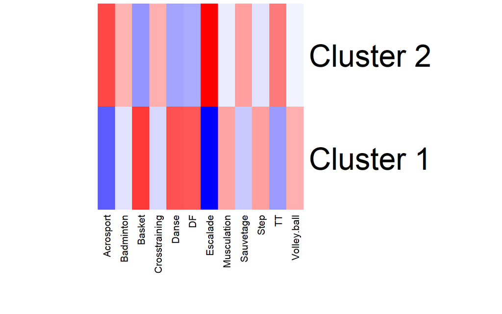

```r
# Visualisation des résidus standardisés sous forme de heatmap
heatmap(residuals, Rowv = NA, Colv = NA, col = colorRampPalette(c("blue", "white", "red"))(100), scale = "none", margins = c(10, 10))
```

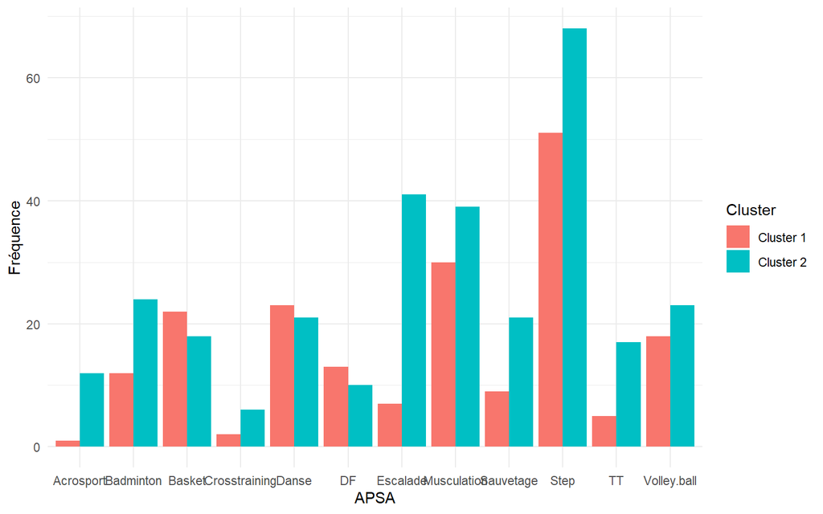

```r
# Visualisation avec ggplot2
# Convertir le tableau de contingence en data.frame pour ggplot2
df <- as.data.frame(as.table(effectifs))

# Graphique en barre empilé
ggplot(df, aes(x = Var2, y = Freq, fill = Var1)) +
  geom_bar(stat = "identity", position = "dodge") +
  labs(x = "APSA", y = "Fréquence", fill = "Cluster") +
  theme_minimal()
```

```r
library(car)
library(DescTools)
effectifs <- matrix(c(103, 171 , # Cluster 1
                      90, 129),
                    nrow = 2, byrow = TRUE)

#plus simple au finale
tab <- table(questiwclust$Sexe, questiwclust$Cluster)
G_sq_test <- GTest(tab)
print(G_sq_test)
```

```
##
##  Log likelihood ratio (G-test) test of independence without correction
##
## data:  tab
## G = 0.62698, X-squared df = 1, p-value = 0.4285
```

```r
# Nommer les lignes et colonnes de la table
rownames(effectifs) <- c("Cluster 1", "Cluster 2")
colnames(effectifs) <- c("F", "M")

# Afficher la table de contingence
print(effectifs)
```

```
##             F   M
## Cluster 1 103 171
## Cluster 2  90 129
```

```r
chi2_test <- chisq.test(effectifs)
effectifs_attendus <- chi2_test$expected
print(effectifs_attendus)
```

```
##                   F        M
## Cluster 1 107.26572 166.7343
## Cluster 2  85.73428 133.2657
```

```r
#regle cochran vérifié

# Effectuer le test du chi-deux

print(chi2_test)
```

```
##
##  Pearson's Chi-squared test with Yates' continuity correction
##
## data:  effectifs
## X-squared = 0.48906, df = 1, p-value = 0.4843
```

```r
GTest(effectifs)
```

```
##
##  Log likelihood ratio (G-test) test of independence without correction
##
## data:  effectifs
## G = 0.62698, X-squared df = 1, p-value = 0.4285
```

```r
tab <- table(questiwclust$Sexe, questiwclust$APSA, questiwclust$Cluster)

print(tab)
```

```
## , ,  = 1
##
##
##     Acrosport Badminton Basket Crosstraining Danse DF Escalade Musculation
##   F         0         5     13             0    11  3        6          21
##   M         1         7      9             2    12 10        1           9
##
##     Sauvetage Step TT Volley-ball
##   F         0   30  4          10
##   M         9   21  1           8
##
## , ,  = 2
##
##
##     Acrosport Badminton Basket Crosstraining Danse DF Escalade Musculation
##   F         9         6      9             4    16  5       23          21
##   M         3        18      9             2     5  5       18          18
##
##     Sauvetage Step TT Volley-ball
##   F         7   51  9          11
##   M        14   17  8          12
```

```r
#permet d'afficher les effectifs de sexe en fonction d'APSA pour le cluster 1 puis le cluster 2


#dans le cluster 1
tab_cluster1 <- tab[,,1]
chi_sq_test_cluster1 <- chisq.test(tab_cluster1)
chi_sq_test_cluster1$expected
```

```
##
##     Acrosport Badminton   Basket Crosstraining    Danse       DF Escalade
##   F 0.5336788  6.404145 11.74093     1.0673575 12.27461 6.937824 3.735751
##   M 0.4663212  5.595855 10.25907     0.9326425 10.72539 6.062176 3.264249
##
##     Musculation Sauvetage     Step       TT Volley-ball
##   F    16.01036  4.803109 27.21762 2.668394    9.606218
##   M    13.98964  4.196891 23.78238 2.331606    8.393782
```

```r
print(chi_sq_test_cluster1)
```

```
##
##  Pearson's Chi-squared test
##
## data:  tab_cluster1
## X-squared = 28.107, df = 11, p-value = 0.003117
```

```r
fisher_test_cluster1 <- fisher.test(tab_cluster1,simulate.p.value=TRUE)
print(fisher_test_cluster1)
```

```
##
##  Fisher's Exact Test for Count Data with simulated p-value (based on
##  2000 replicates)
##
## data:  tab_cluster1
## p-value = 0.001999
## alternative hypothesis: two.sided
```

```r
#dans le cluster 2
tab_cluster2 <- tab[,,2]
chi_sq_test_cluster2 <- chisq.test(tab_cluster2)
chi_sq_test_cluster2$expected
```

```
##
##     Acrosport Badminton Basket Crosstraining Danse  DF Escalade Musculation
##   F      6.84     13.68  10.26          3.42 11.97 5.7    23.37       22.23
##   M      5.16     10.32   7.74          2.58  9.03 4.3    17.63       16.77
##
##     Sauvetage  Step   TT Volley-ball
##   F     11.97 38.76 9.69       13.11
##   M      9.03 29.24 7.31        9.89
```

```r
# plutot fisher
fisher_test_cluster2 <- fisher.test(tab_cluster2,simulate.p.value=TRUE)
print(fisher_test_cluster2)
```

```
##
##  Fisher's Exact Test for Count Data with simulated p-value (based on
##  2000 replicates)
##
## data:  tab_cluster2
## p-value = 0.001499
## alternative hypothesis: two.sided
```

J’arrive a die que peu importe le cluster il n’y a pas indépendance entre APSA et Sexe.

```r
effectifs <-t( matrix(c(0, 9,
                      5, 6,
                      13, 9,
                      0, 4,
                      11, 16,
                      3, 5,
                      6, 23,
                      21, 21,
                      0, 7,
                      30, 51,
                      4, 9,
                      10, 11,
                      1, 3,
                      7, 18,
                      9, 9,
                      2, 2,
                      12,5 ,
                      10,5 ,
                      1, 18,
                      9, 18,
                      9, 14,
                      21, 17,
                      1, 8,
                      8, 12),
                    nrow = 24, byrow = TRUE))

# Nommer les lignes et colonnes de la table
colnames(effectifs) <- c("FAcrosport", "Badminton", "Basket", "Crosstraining",
                         "Danse", "DF", "Escalade", "Musculation",
                         "Sauvetage", "Step", "TT", "Volley.ball", "GAcrosport", "Badminton", "Basket", "Crosstraining",
                         "Danse", "DF", "Escalade", "Musculation",
                         "Sauvetage", "Step", "TT", "Volley.ball")
rownames(effectifs) <- c("Cluster 1", "Cluster 2")

# Vérification des effectifs totaux par cluster
totals <- rowSums(effectifs)
print("Effectifs totaux par cluster :")
```

```
## [1] "Effectifs totaux par cluster :"
```

```r
print(totals)
```

```
## Cluster 1 Cluster 2
##       193       300
```

```r
# Normalisation des effectifs
normalized_effectifs <- sweep(effectifs, 1, totals, FUN = "/")
print("Effectifs normalisés :")
```

```
## [1] "Effectifs normalisés :"
```

```r
print(normalized_effectifs)
```

```
##           FAcrosport  Badminton     Basket Crosstraining      Danse         DF
## Cluster 1       0.00 0.02590674 0.06735751    0.00000000 0.05699482 0.01554404
## Cluster 2       0.03 0.02000000 0.03000000    0.01333333 0.05333333 0.01666667
##             Escalade Musculation  Sauvetage      Step         TT Volley.ball
## Cluster 1 0.03108808   0.1088083 0.00000000 0.1554404 0.02072539  0.05181347
## Cluster 2 0.07666667   0.0700000 0.02333333 0.1700000 0.03000000  0.03666667
##            GAcrosport  Badminton     Basket Crosstraining      Danse         DF
## Cluster 1 0.005181347 0.03626943 0.04663212   0.010362694 0.06217617 0.05181347
## Cluster 2 0.010000000 0.06000000 0.03000000   0.006666667 0.01666667 0.01666667
##              Escalade Musculation  Sauvetage       Step          TT Volley.ball
## Cluster 1 0.005181347  0.04663212 0.04663212 0.10880829 0.005181347  0.04145078
## Cluster 2 0.060000000  0.06000000 0.04666667 0.05666667 0.026666667  0.04000000
```

```r
# Afficher la table de contingence
print(effectifs)
```

```
##           FAcrosport Badminton Basket Crosstraining Danse DF Escalade
## Cluster 1          0         5     13             0    11  3        6
## Cluster 2          9         6      9             4    16  5       23
##           Musculation Sauvetage Step TT Volley.ball GAcrosport Badminton Basket
## Cluster 1          21         0   30  4          10          1         7      9
## Cluster 2          21         7   51  9          11          3        18      9
##           Crosstraining Danse DF Escalade Musculation Sauvetage Step TT
## Cluster 1             2    12 10        1           9         9   21  1
## Cluster 2             2     5  5       18          18        14   17  8
##           Volley.ball
## Cluster 1           8
## Cluster 2          12
```

```r
chi2_test <- chisq.test(effectifs)
effectifs_attendus <- chi2_test$expected
print(effectifs_attendus)
```

```
##           FAcrosport Badminton    Basket Crosstraining    Danse       DF
## Cluster 1   3.523327  4.306288  8.612576      1.565923 10.56998 3.131846
## Cluster 2   5.476673  6.693712 13.387424      2.434077 16.43002 4.868154
##           Escalade Musculation Sauvetage     Step       TT Volley.ball
## Cluster 1 11.35294    16.44219  2.740365 31.70994 5.089249    8.221095
## Cluster 2 17.64706    25.55781  4.259635 49.29006 7.910751   12.778905
##           GAcrosport Badminton    Basket Crosstraining     Danse       DF
## Cluster 1   1.565923  9.787018  7.046653      1.565923  6.655172 5.872211
## Cluster 2   2.434077 15.212982 10.953347      2.434077 10.344828 9.127789
##            Escalade Musculation Sauvetage     Step       TT Volley.ball
## Cluster 1  7.438134    10.56998  9.004057 14.87627 3.523327    7.829615
## Cluster 2 11.561866    16.43002 13.995943 23.12373 5.476673   12.170385
```

```r
#regle cochran pas vérifié



fisher_test <- fisher.test(effectifs, simulate.p.value = TRUE)
print(fisher_test)
```

```
##
##  Fisher's Exact Test for Count Data with simulated p-value (based on
##  2000 replicates)
##
## data:  effectifs
## p-value = 0.0004998
## alternative hypothesis: two.sided
```

Il n’y a pas independance entre sexe+APSA et Cluster